# Exploratory Data Analysis Report

2019-03-15

## Exploratory Data analysis (EDA)

Analyzing the data sets to summarize their main characteristics of variables, often with visual graphs, without using a statistical model.

### 1. Overview of the data

Understanding the dimensions of the dataset, variable names, overall missing summary and data types of each variables

```r
# Overiview of the data
ExpData(data=data,type=1)
# Structure of the data
ExpData(data=data,type=2)
```

**Overview of the data**

| Descriptions | Obs |
| --- | --- |
| Sample size (Nrow) | 6537 |
| No. of Variables (Ncol) | 14 |
| No. of Numeric Variables | 7 |
| No. of Factor Variables | 2 |
| No. of Text Variables | 4 |
| No. of Logical Variables | 0 |
| No. of Date Variables | 1 |
| No. of Zero variance Variables (Uniform) | 0 |
| %. of Variables having complete cases | 78.57% (11) |
| %. of Variables having <50% missing cases | 14.29% (2) |

[output cut: 2 more lines]

**Structure of the data**

| S.no | Variable Name | Variable Type | % of Missing | No. of Unique values |
| --- | --- | --- | --- | --- |
| 1 | sex* | character | 0 | 2 |
| 2 | age | numeric | 0 | 65 |
| 3 | race* | factor | 0 | 6 |
| 4 | juv_fel_count | numeric | 0 | 11 |
| 5 | juv_misd_count | numeric | 0 | 10 |
| 6 | juv_other_count | numeric | 0 | 11 |
| 7 | priors_count | numeric | 0 | 33 |
| 8 | c_offense_date** | Date | 0.13 | 751 |
| 9 | c_arrest_date* | character | 0.87 | 475 |
| 10 | c_charge_degree* | character | 0 | 12 |

[output cut: 4 more lines]

**Target variable**

Summary of categorical dependent variable

```
##   is_recid Frequency Descriptions
## 1        0      4317     is_recid
## 2        1      2220     is_recid
```

### 2. Summary of numerical variables

Summary of all numerical variables

Summary statistics when dependent variable is categorical **is_recid**. Summary statistics will be splitted into category level

```r
ExpNumStat(data,by="GA",gp=Target,Qnt=seq(0,1,0.1),MesofShape=2,Outlier=TRUE,round=2)
```

| Vname | Group | TN | nNeg | nZero | nPos | NegInf | PosInf | NA_Value | Per_of_Missing | sum | min | max | mean | median | SD | CV | IQR | Skweness | Kurtosis | 0% | 10% | 20% | 30% | 40% | 50% | 60% | 70% | 80% | 90% | … |
| --- | --- | --- | --- | --- | --- | --- | --- | --- | --- | --- | --- | --- | --- | --- | --- | --- | --- | --- | --- | --- | --- | --- | --- | --- | --- | --- | --- | --- | --- | --- |
| age | is_recid:All | 6537 | 0 | 0 | 6537 | 0 | 0 | 0 | 0.00 | 226707.00 | 18.00 | 96.00 | 34.68 | 31.00 | 11.88 | 0.34 | 17.00 | 0.91 | 0.15 | 18.00 | 22.00 | 24.00 | 26.00 | 29.00 | 31.00 | 35.00 | 39.00 | 45.00 | 53.00 | … |
| age | is_recid:0 | 4317 | 0 | 0 | 4317 | 0 | 0 | 0 | 0.00 | 155500.00 | 18.00 | 83.00 | 36.02 | 33.00 | 12.28 | 0.34 | 18.00 | 0.77 | -0.19 | 18.00 | 22.00 | 25.00 | 27.00 | 30.00 | 33.00 | 37.00 | 42.00 | 47.00 | 54.00 | … |
| age | is_recid:1 | 2220 | 0 | 0 | 2220 | 0 | 0 | 0 | 0.00 | 71207.00 | 18.00 | 96.00 | 32.08 | 29.00 | 10.59 | 0.33 | 13.00 | 1.21 | 1.20 | 18.00 | 21.00 | 23.00 | 25.00 | 27.00 | 29.00 | 31.00 | 35.00 | 40.00 | 49.00 | … |
| age_at_offense | is_recid:All | 6537 | 0 | 0 | 5688 | 0 | 0 | 849 | 12.99 | 186664.14 | 15.04 | 94.52 | 32.82 | 29.68 | 11.89 | 0.36 | 17.18 | 0.92 | 0.18 | 15.04 | 20.05 | 22.13 | 24.48 | 26.76 | 29.68 | 33.03 | 37.27 | 43.33 | 50.76 | … |
| age_at_offense | is_recid:0 | 4317 | 0 | 0 | 3748 | 0 | 0 | 569 | 13.18 | 128147.19 | 15.04 | 79.89 | 34.19 | 31.35 | 12.28 | 0.36 | 18.38 | 0.77 | -0.18 | 15.04 | 20.47 | 22.82 | 25.35 | 28.01 | 31.35 | 34.80 | 39.75 | 45.56 | 52.70 | … |
| age_at_offense | is_recid:1 | 2220 | 0 | 0 | 1940 | 0 | 0 | 280 | 12.61 | 58516.95 | 17.81 | 94.52 | 30.16 | 27.15 | 10.60 | 0.35 | 13.17 | 1.23 | 1.34 | 17.81 | 19.28 | 21.18 | 22.99 | 25.14 | 27.15 | 29.62 | 33.09 | 38.13 | 46.67 | … |
| jail_days | is_recid:All | 6537 | 0 | 0 | 6537 | 0 | 0 | 0 | 0.00 | 7465940.00 | 29.00 | 10592.00 | 1142.10 | 366.00 | 1614.34 | 1.41 | 731.00 | 2.86 | 8.55 | 29.00 | 365.00 | 365.00 | 365.00 | 365.00 | 366.00 | 730.00 | 731.00 | 1461.00 | 2953.00 | … |
| jail_days | is_recid:0 | 4317 | 0 | 0 | 4317 | 0 | 0 | 0 | 0.00 | 4536901.00 | 29.00 | 10349.00 | 1050.94 | 366.00 | 1548.03 | 1.47 | 366.00 | 3.12 | 10.38 | 29.00 | 365.00 | 365.00 | 365.00 | 365.00 | 366.00 | 366.00 | 731.00 | 1096.00 | 2588.00 | … |
| jail_days | is_recid:1 | 2220 | 0 | 0 | 2220 | 0 | 0 | 0 | 0.00 | 2929039.00 | 29.00 | 10592.00 | 1319.39 | 395.50 | 1722.66 | 1.31 | 1096.00 | 2.46 | 6.11 | 29.00 | 365.00 | 365.00 | 365.00 | 366.00 | 395.50 | 731.00 | 1096.00 | 1827.00 | 3652.00 | … |
| juv_fel_count | is_recid:All | 6537 | 0 | 6335 | 202 | 0 | 0 | 0 | 0.00 | 369.00 | 0.00 | 20.00 | 0.06 | 0.00 | 0.47 | 8.38 | 0.00 | 20.32 | 642.08 | 0.00 | 0.00 | 0.00 | 0.00 | 0.00 | 0.00 | 0.00 | 0.00 | 0.00 | 0.00 | … |

[output cut: 11 more lines]

### 3. Distributions of Numerical variables

- Box plots for all numerical variables vs categorical dependent variable - Bivariate comparision only with categories
- Quantile-quantile plot(Univariate)
- Density plot (Univariate)
- Box plot (univariate and Bivariate)

#### Quantile-quantile plot for Numerical variables - Univariate

Quantile-quantile plot for all Numerical variables

```r
ExpOutQQ(data,nlim=4,fname=NULL,Page=c(2,2),sample=sn)
```

```
## $`0`
```

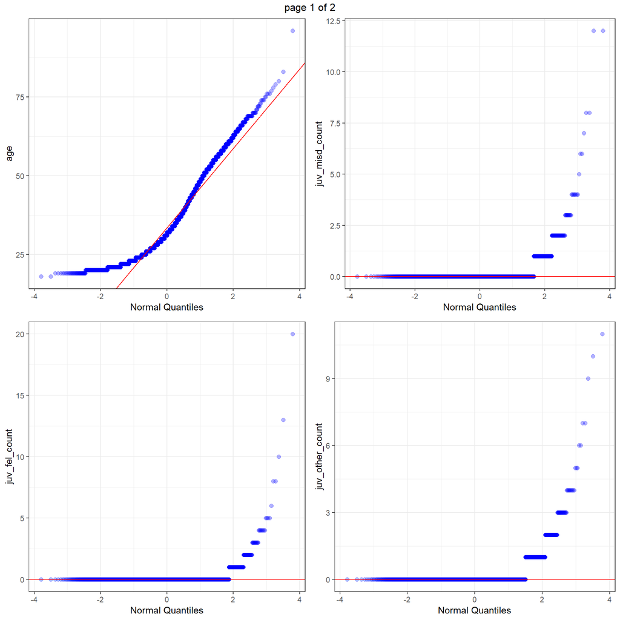

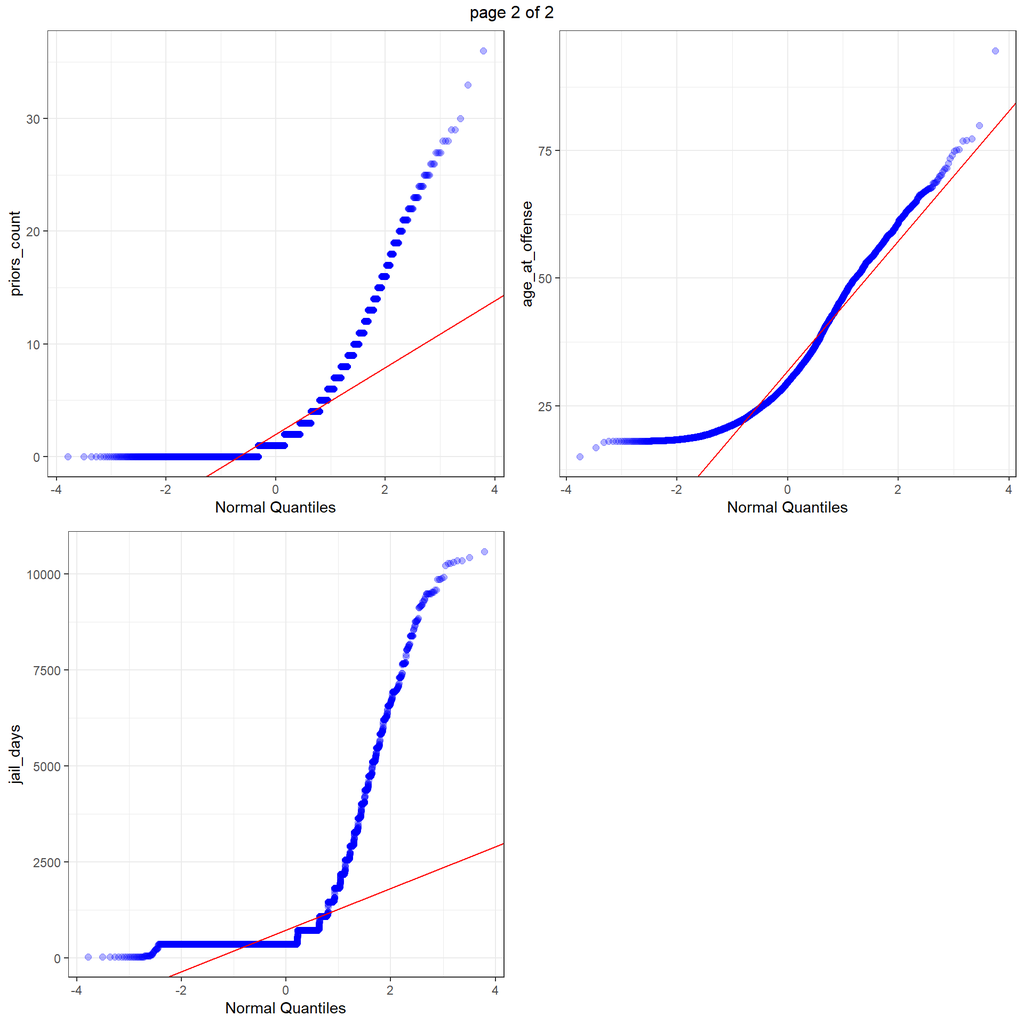

#### Density plots for Numerical variables - Univariate

Density plot for all Numerical variables

```
## $`0`
```

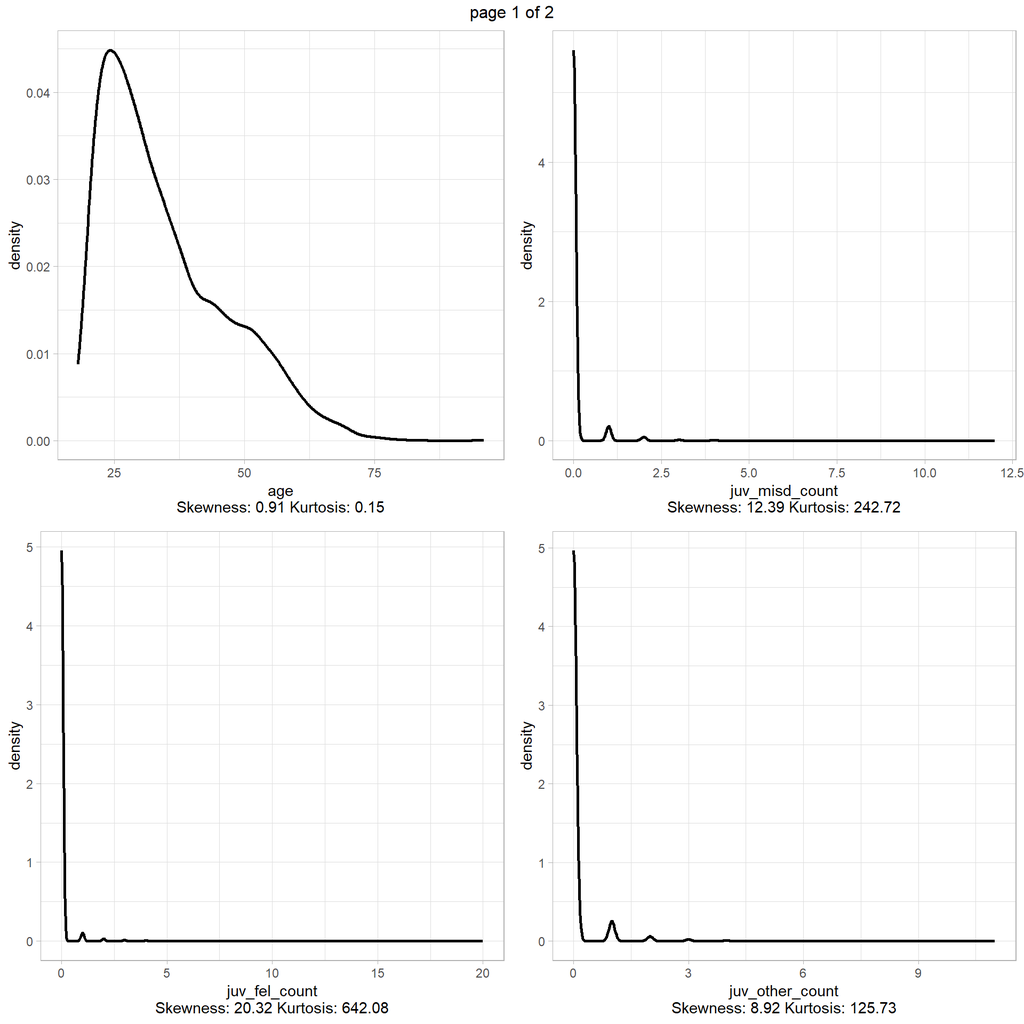

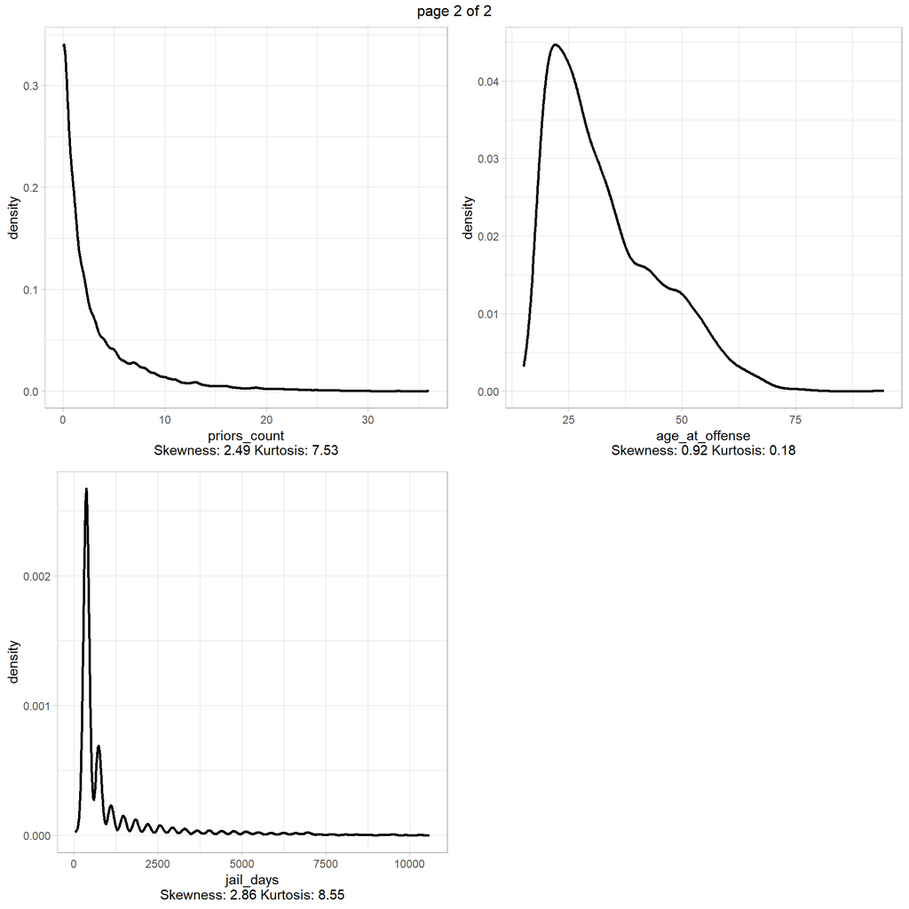

```r
ExpNumViz(data,gp=NULL,type=1,nlim=NULL,fname=NULL,col=NULL,Page=c(2,2),sample=sn)
```

#### Box plots for all numeric features vs categorical dependent variable - Bivariate comparision only with categories

Boxplot for all the numeric attributes by each category of **is_recid**

```
## $`0`
```

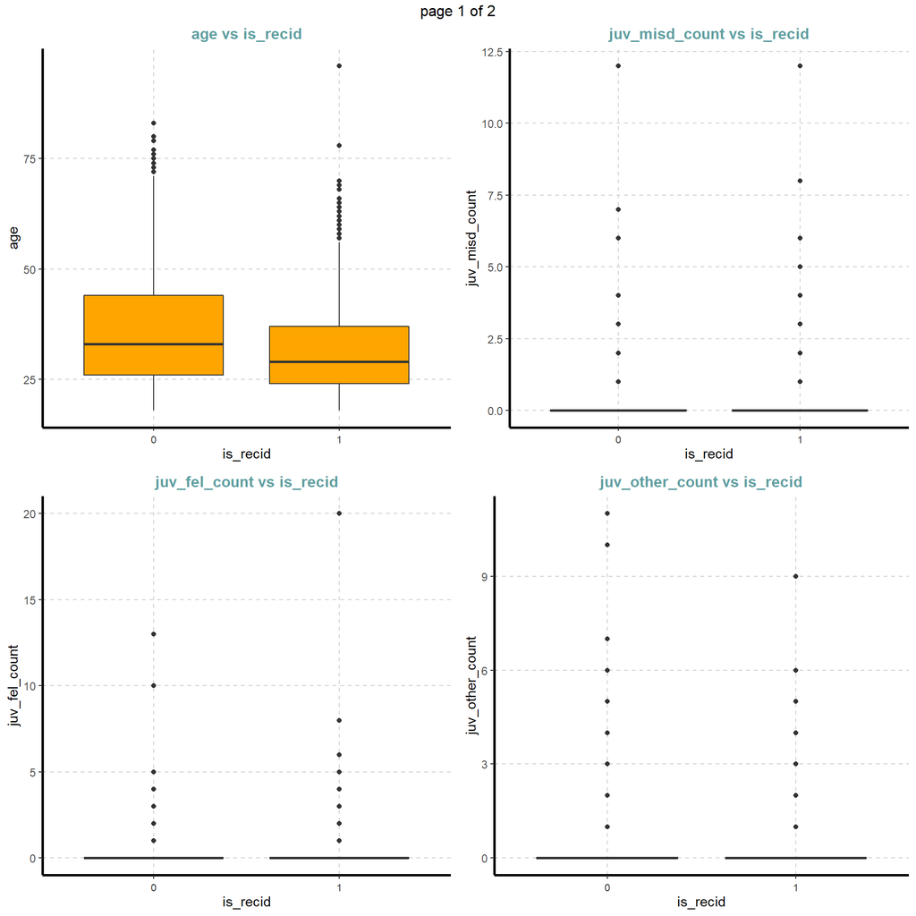

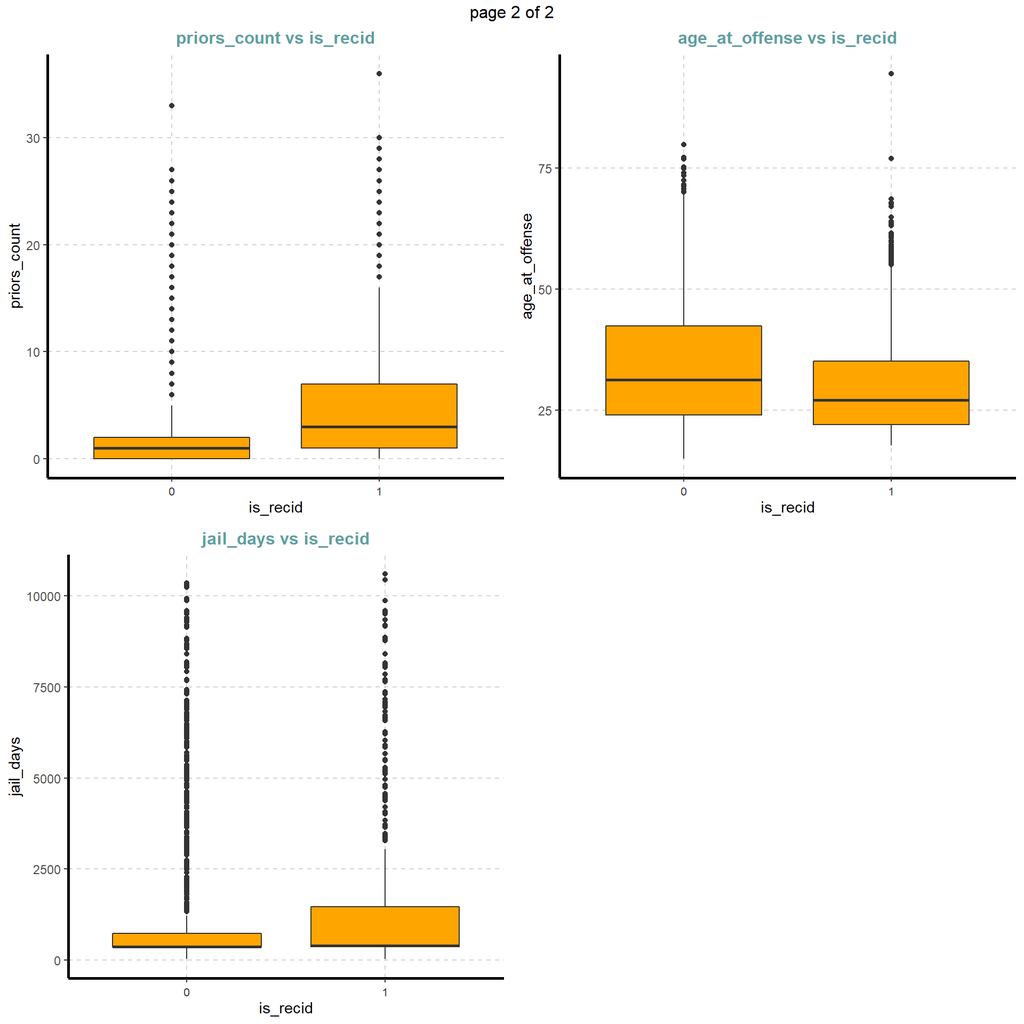

```r
ExpNumViz(data,gp=Target,type=2,nlim=NULL,fname=NULL,col=NULL,Page=c(2,2),sample=sn)
```

### 4. Summary of categorical variables

Summary of categorical variable

**Cross tabulation with target variable**

- Custom tables between all categorical independent variables and traget variable **is_recid**

```r
ExpCTable(data,Target=Target,margin=1,clim=10,nlim=NULL,round=2,bin=NULL,per=F)
```

| VARIABLE | CATEGORY | is_recid:0 | is_recid:1 | TOTAL |
| --- | --- | --- | --- | --- |
| sex | Female | 1011 | 331 | 1342 |
| sex | Male | 3306 | 1889 | 5195 |
| sex | TOTAL | 4317 | 2220 | 6537 |
| race | African-American | 1956 | 1301 | 3257 |
| race | Asian | 27 | 6 | 33 |
| race | Caucasian | 1606 | 650 | 2256 |
| race | Hispanic | 386 | 149 | 535 |
| race | Native American | 10 | 5 | 15 |
| race | Other | 332 | 109 | 441 |
| race | TOTAL | 4317 | 2220 | 6537 |

**Information Value**

```r
ExpCatStat(data,Target=Target,Label=label,result = "IV",clim=10,nlim=5,Pclass=Rc)
```

| Variable | Target | Class | Out_1 | Out_0 | TOTAL | Per_1 | Per_0 | Odds | WOE | IV | Ref_1 | Ref_0 |
| --- | --- | --- | --- | --- | --- | --- | --- | --- | --- | --- | --- | --- |
| sex | is_recid | Female | 1011 | 331 | 1342 | 0.234 | 0.149 | 1.570 | 0.451 | 0.038 | 0 | 1 |
| sex | is_recid | Male | 3306 | 1889 | 5195 | 0.766 | 0.851 | 0.900 | -0.105 | 0.009 | 0 | 1 |
| race | is_recid | African-American | 1956 | 1301 | 3257 | 0.453 | 0.586 | 0.773 | -0.257 | 0.034 | 0 | 1 |
| race | is_recid | Asian | 27 | 6 | 33 | 0.006 | 0.003 | 2.000 | 0.693 | 0.002 | 0 | 1 |
| race | is_recid | Caucasian | 1606 | 650 | 2256 | 0.372 | 0.293 | 1.270 | 0.239 | 0.019 | 0 | 1 |
| race | is_recid | Hispanic | 386 | 149 | 535 | 0.089 | 0.067 | 1.328 | 0.284 | 0.006 | 0 | 1 |
| race | is_recid | Native American | 10 | 5 | 15 | 0.002 | 0.002 | 1.000 | 0.000 | 0.000 | 0 | 1 |
| race | is_recid | Other | 332 | 109 | 441 | 0.077 | 0.049 | 1.571 | 0.452 | 0.013 | 0 | 1 |

**Statistical test**

```r
ExpCatStat(data,Target=Target,Label=label,result = "Stat",clim=10,nlim=5,Pclass=Rc)
```

| Variable | Target | Unique | Chi-squared | p-value | df | IV Value | Cramers V | Degree of Association | Predictive Power |
| --- | --- | --- | --- | --- | --- | --- | --- | --- | --- |
| sex | is_recid | 2 | 64.544 | 0 | 1 | 0.047 | 0.1 | Weak | Not Predictive |
| race | is_recid | 6 | 108.044 | 0 | 5 | 0.074 | 0.13 | Weak | Not Predictive |

### 5. Distributions of categorical variables

Graphical representation of all categorical variables

- Bar plot (Univariate)
- Stacked Bar plot (Bivariate)

**Bar plots for all categorical variables**

- Bar plot with vertical or horizontal bars for all categorical variables

```
## $`0`
```

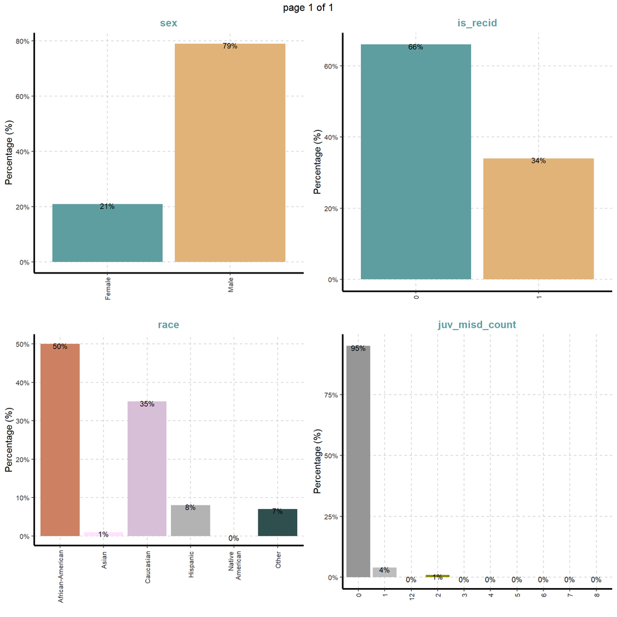

```r
ExpCatViz(data,gp=NULL,fname=NULL,clim=10,margin=2,Page = c(2,2),sample=sc)
```

- Stacked bar plot with vertical or horizontal bars for all categorical variables

```
## $`0`
```

[figure not shown]

```r
ExpCatViz(data,gp=Target,fname=NULL,clim=10,margin=2,Page = c(2,2),sample=sc)
```